# Inference Edx coruse

Jorge Gómez

6/23/2021

**Note: the following notes are done following the Data Science: Inference and Modeling course from EdX. The scenario in which all exercises are implemented is an election poll in the U.S.A.**

# Section 1, Parameters and Estimates

## Objectives

1. Understand how to use a sampling model to perform a poll.
2. Explain the terms population, parameter, and sample as they relate to statistical inference.
3. Use a sample to estimate the population proportion from the sample average.
4. Calculate the expected value and standard error of the sample average.

#### Key words

1. **Population**: the collection of elements.
2. **Parameter**: number that summarizes the data from the entire population.
3. **Sample**: observed data from a subset of the population.
4. **Estimate**: summary of the data in a parameter, it’s driven by the parameter.

### Sampling Model Parameters and Estimates

Loads the needed library and sets an example of a sample of 25 that have two possible states. In this case, the *urn* from which the sample is taken, doesn´t show itlsef so that we have to estimate the proportion of the balls

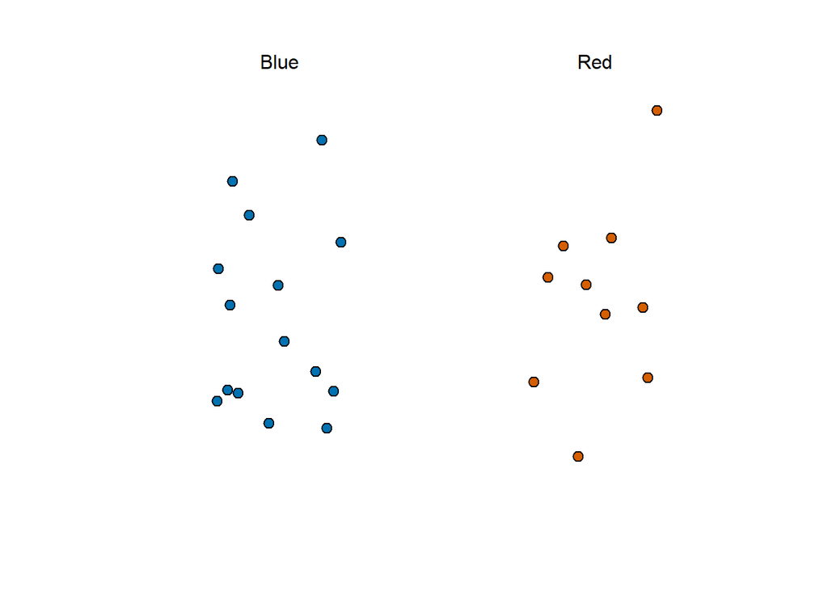

```r
library(tidyverse)
library(dslabs)
ds_theme_set()
take_poll(25)#takes a random sample of an urn withg red and blue balls, it is with replacements
```

The total of blue balls shall be represented as *p*, so the total of red balls is represented as *1-p*. The spread of said balls would be then *p-(1-p)* or simplified as *2p-1*. The total of beads, or any total of any other type of subjects, is called **population**; while, in this case, the proportion of blue balls would be a **parameter**, and the balls that were taken from the urn would be known as **sample**.

The task of statistical inference, in this particular case, would be to predict the parameter, *p*, using the observed data in the sample. The samples taken are informative, but are not a true representation of the whole, however, its information is certainly helpful. With inference, we want to generate an **estimate**, which is a summary of the data we have/observe. It is importanty to know that the samples are informative, but are prone to error since, at least in this case, they are random, meaning every time the function to take a sample from the urn, would give a different result and a different value of *p*.

### The Sample Average

When we have the parameter, *p*, it is easy to get the value of the spread, *2p-1*. To illustrate, in this imaginary example, every time the a blue balls get sampled it would have a value of 1, while getting a red balls would have a value of 0, so in order to get the proportion from a *N* number of samples, it would simply be illustrated like this.
$$\bar{X}=\frac{X_1+X_2+X_3+...+X_n}{N}$$
If we have multiple samples that are randomly taken, it would look like this.
$$N\bar{X}=\frac{X_1+X_2+X_3+...+X_n}{N}$$
Since *N* is not a variable, meaning that the value we already know, then this equation can be performed and determine the distribution of the average taken from all the samples. The estimate that is calculated and gves a value of *p* is waht we’re trying to find, since the proportion of the colour balls in the urn is still unknown. To define unknown parts of the models, we use the parameters, therefore the paramter *p* is exactly what we want.The parameters are what we want to determine in each scenario.

### Polling versus Forecasting

The problem of forecasting lies on that you’re estimating the parameters in the moment of the sample, not after, nor before, therefore, when applied it may vary from the forecast. Nontheless, some implementations can be done in order to consider how the parameters may fluctuate in time, thoguh it is still forecasting and cannot possibly take every variable into consideration for an exact estimate.

### Exercises

#### Ex. 1

1. Suppose you poll a population in which a proportion *p* of voters are Democrats and *1-p* are Republicans. Your sample size is *N=25*. Consider the random variable *S*, which is the total number of Democrats in your sample. What is the expected value of this random variable *S*?

**Answer:**
$$E(S)=25p$$

#### Ex. 2

Again, consider the random variable *S*, which is the total number of Democrats in your sample of 25 voters. The variable *p* describes the proportion of Democrats in the sample, whereas *1-p* describes the proportion of Republicans. What is the standard error of *S*?

**Answer:**
$$SE(S)=\sqrt{25p(1-p)}$$

#### Ex. 3

Consider the random variable *S/N*, which is equivalent to the sample average that we have been denoting as *X*. The variable *N* represents the sample size and is the proportion of Democrats in the population. What is the expected value of *X*?

**Answer:**
$$E(\bar{X})=p$$

#### Ex. 4

What is the standard error of the sample average, *X*? The variable *N* represents the sample size and is the proportion of Democrats in the population.

**Answer:**
$$SE(\bar{X})=\sqrt{p(1-p)/N}$$

#### Ex. 5

1. Write a line of code that calculates the standard error se of a sample average when you poll 25 people in the population. Generate a sequence of 100 proportions of Democrats p that vary from 0 (no Democrats) to 1 (all Democrats). Plot se versus p for the 100 different proportions.
2. Use the seq function to generate a vector of 100 values of p that range from 0 to 1.
3. Use the sqrt function to generate a vector of standard errors for all values of p.
4. Use the plot function to generate a plot with p on the x-axis and se on the y-axis.

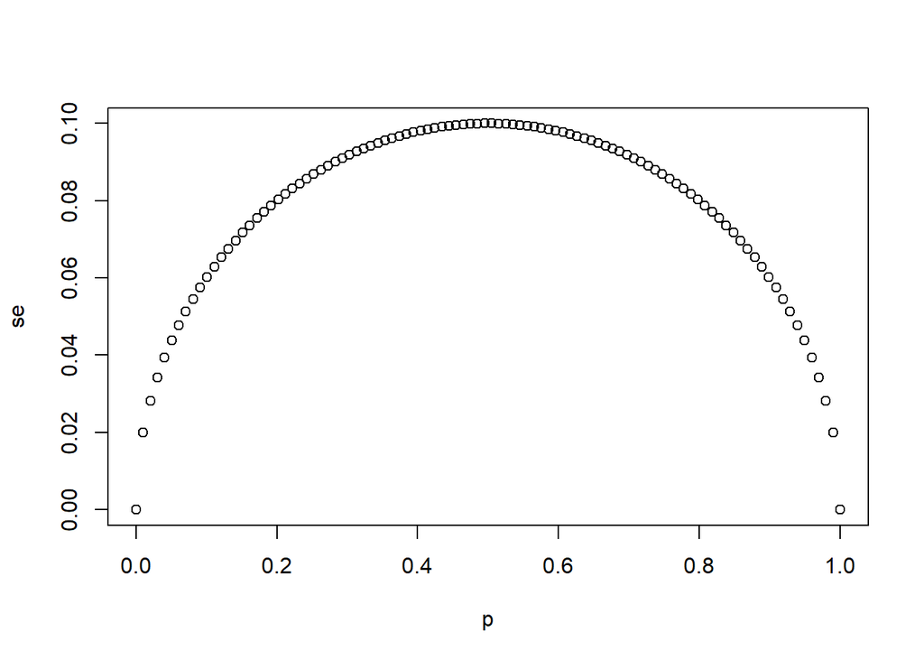

```r
# `N` represents the number of people polled
N <- 25

# Create a variable `p` that contains 100 proportions ranging from 0 to 1 using the `seq` function
p<-seq(0,1, length.out = 100)

# Create a variable `se` that contains the standard error of each sample average
se<-sqrt(p*(1-p)/N)

# Plot `p` on the x-axis and `se` on the y-axis
plot(p,se)
```

#### Ex. 6

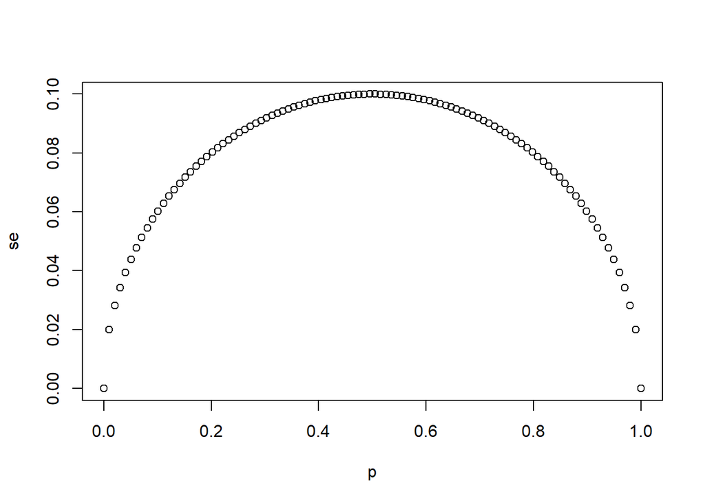

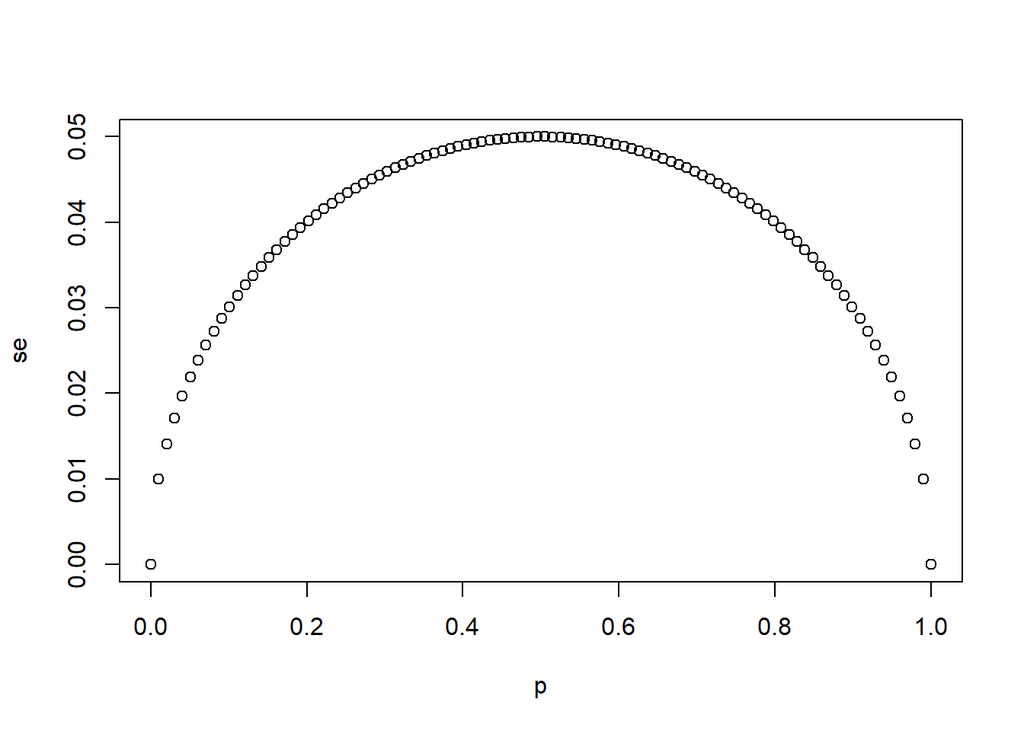

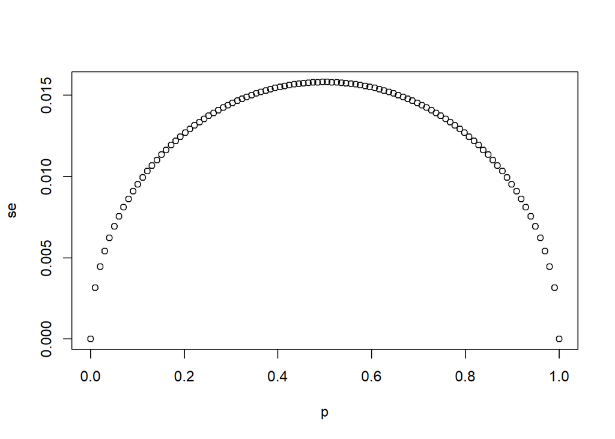

```r
# The vector `p` contains 100 proportions of Democrats ranging from 0 to 1 using the `seq` function
p <- seq(0, 1, length = 100)

# The vector `sample_sizes` contains the three sample sizes
sample_sizes <- c(25, 100, 1000)

# Write a for-loop that calculates the standard error `se` for every value of `p` for each of the three samples sizes `N` in the vector `sample_sizes`. Plot the three graphs, using the `ylim` argument to standardize the y-axis across all three plots.

for (i in sample_sizes) {
  se<-sqrt(p*(1-p)/i)
  plot(p,se,ylim = c(0,max(se)))
}
```

#### Ex. 7

Our estimate for the difference in proportions of Democrats and Republicans is *d=X-(1-X)*. Which derivation correctly uses the rules we learned about sums of random variables and scaled random variables to derive the expected value of *d*?

**Answer:**
$$E[\bar{X}-(1-\bar{X})]=E[2\bar{X}-1]=2E[\bar{X}]-1=2p-1=p-(1-p)$$

#### Ex. 8

Our estimate for the difference in proportions of Democrats and Republicans is *d=X-(1-X)*.Which derivation correctly uses the rules we learned about sums of random variables and scaled random variables to derive the standard error of *d*?

**Answer:**
$$SE[\bar{X}-(1-\bar{X})]=SE[2\bar{X}-1]=2SE[\bar{X}]=2\sqrt{p(1-p)/N}$$

#### Ex. 9

1. Say the actual proportion of Democratic voters is *p=0.45*. In this case, the Republican party is winning by a relatively large margin of *d= -0.1*, or a 10% margin of victory. What is the standard error of the spread *2X-1* in this case?
2. Use the sqrt function to calculate the standard error of the spread *2X-1*.

```r
# `N` represents the number of people polled
N <- 25

# `p` represents the proportion of Democratic voters
p <- 0.45

# Calculate the standard error of the spread. Print this value to the console.

2*sqrt(p*(1-p)/N)
```

```
## [1] 0.1989975
```

#### Ex. 10

1. So far we have said that the difference between the proportion of Democratic voters and Republican voters is about 10% and that the standard error of this spread is about 0.2 when *N=25*. Select the statement that explains why this sample size is sufficient or not.

**Answer:**This sample size is too small because the standard error is larger than the spread.

# Section 2, The Central Limit Theorem in Practice

## Objectives

1. Use the Central Limit Theorem to calculate the probability that a sample estimate *X* is close to the population proportion *p*.
2. Run a Monte Carlo simulation to corroborate theoretical results built using probability theory.
3. Estimate the spread based on estimates of *X* and *SE(X)*.
4. Understand why bias can mean that ñarger samples sizes aren’t necessarily better.